# YouTube Comments Analysis — CRISP-DM

**Video:** "Can I Vibecode a $250M App Better Than a Pro Developer?" — Riley **Comments:** ~3,007 | **Date:** 2026-04-06

```python
import json, re, warnings
from pathlib import Path
from collections import Counter
from itertools import combinations

import numpy as np
import pandas as pd
import matplotlib.pyplot as plt
import seaborn as sns
import plotly.express as px
import networkx as nx
import ollama
import umap
import hdbscan
from sentence_transformers import SentenceTransformer
from sklearn.metrics.pairwise import cosine_similarity
from sklearn.metrics import silhouette_score
from vaderSentiment.vaderSentiment import SentimentIntensityAnalyzer

warnings.filterwarnings('ignore')
pd.set_option('display.max_colwidth', 120)
plt.rcParams['figure.figsize'] = (12, 6)
plt.rcParams['figure.dpi'] = 100

DATA_RAW       = Path('data/raw/comments.json')
DATA_CLEAN     = Path('data/processed/comments_clean.csv')
EMBEDDINGS_PATH = Path('data/processed/embeddings.npy')
CLUSTERS_PATH  = Path('data/processed/clusters.csv')

CONCEPTS = [
    'ide', 'terminal', 'vibe coding', 'vibe code', 'vibecod',
    'ai', 'artificial intelligence', 'cursor', 'real developer',
    'no code', 'nocode', 'tts', 'transcription', 'coding', 'programmer',
    'fear', 'easy', 'impossible', 'future', 'replace',
    'cheat', 'shortcut', 'real coding', 'fake'
]
print("✓ Setup completo")
```

```
✓ Setup completo
```

# Fase 1: Business Understanding

## Contexto

Riley publicó "Can I Vibecode a $250M App Better Than a Pro Developer? (With No Code)". El video muestra a un no-programador construyendo una app real usando herramientas de IA, sin entender conceptos como IDE, terminal, o cómo funciona la transcripción del iPhone.

## Preguntas de Negocio

1. ¿Cuál es el sentimiento general hacia el video y hacia el vibe coding?
2. ¿Qué perfil tiene la persona que comenta? (coder, vibe-coder, casual, técnico)
3. ¿Las personas técnicas sienten amenaza/escepticismo ante el vibe coding?
4. ¿Las personas no técnicas se sorprenden de que Riley no entienda cosas básicas?
5. ¿Existe brecha entre "vibe coding es el futuro" vs "no es coding real"?

## Hipótesis

- **H1:** Coders escépticos reaccionan negativamente a la ignorancia técnica de Riley
- **H2:** Vibe coders/fans entusiastas celebran que "no necesitás saber código"
- **H3:** `IDE` y `terminal` generan comentarios de incredulidad o condescendencia
- **H4:** Los técnicos no tienen miedo, sino escepticismo sobre si es "real" coding

# Fase 2: Data Understanding

```python
with open(DATA_RAW, 'r', encoding='utf-8') as f:
    raw_text = f.read().strip()

records = []
parse_mode = None

# Soporta JSON objeto {metadata, comments}, lista JSON pura y JSONL por línea.
try:
    payload = json.loads(raw_text)
    if isinstance(payload, dict) and isinstance(payload.get('comments'), list):
        records = payload['comments']
        parse_mode = 'json_object.comments'
    elif isinstance(payload, list):
        records = payload
        parse_mode = 'json_array'
    else:
        raise ValueError('Estructura JSON no soportada en comments.json')
except json.JSONDecodeError:
    bad_lines = []
    for line_num, line in enumerate(raw_text.splitlines(), 1):
        line = line.strip()
        if not line:
            continue
        try:
            records.append(json.loads(line))
        except json.JSONDecodeError as e:
            bad_lines.append((line_num, str(e)))

    parse_mode = 'jsonl'
    if not records:
        sample = bad_lines[:3]
        raise ValueError(f'No se pudo parsear {DATA_RAW} como JSON ni JSONL. Errores ejemplo: {sample}')

# Normaliza campos numéricos que vienen como texto.
df_raw = pd.DataFrame(records)
if 'votes' in df_raw.columns:
    df_raw['votes'] = pd.to_numeric(df_raw['votes'], errors='coerce').fillna(0).astype(int)
if 'replies' in df_raw.columns:
    df_raw['replies'] = pd.to_numeric(df_raw['replies'], errors='coerce').fillna(0).astype(int)

print(f"Total comentarios: {len(df_raw)}")
print(f"Formato detectado: {parse_mode}")
print(f"Columnas: {list(df_raw.columns)}")
df_raw[['author', 'text', 'votes']].head(3)
```

```
Total comentarios: 3007
Formato detectado: json_object.comments
Columnas: ['cid', 'text', 'time', 'author', 'channel', 'votes', 'replies', 'photo', 'heart', 'reply', 'time_parsed']
```

|  | author | text | votes |
| --- | --- | --- | --- |
| 0 | @rileybrownai | To vote just comment who won below. Riley or Vishal. We're giving away $1000 worth of credits to 5 people for the vi... | 134 |
| 1 | @marvinguerrero | and now I am wondering if the humans in this video were made by AI. pretending to give AI Prompts | 0 |
| 2 | @xxtigers-9xx147 | Vishal | 0 |

```python
print("=== Info del Dataset ===")
print(f"Con likes > 0: {(df_raw['votes'] > 0).sum()} ({(df_raw['votes'] > 0).mean():.1%})")
print(f"Más likeado: {df_raw['votes'].max()} likes")
print("\nTop 5 por likes:")
df_raw.nlargest(5, 'votes')[['author', 'text', 'votes']]
```

```
=== Info del Dataset ===
Con likes > 0: 384 (12.8%)
Más likeado: 595 likes

Top 5 por likes:
```

|  | author | text | votes |
| --- | --- | --- | --- |
| 847 | @wasinhasan01 | The back-and-forth between the devs is fascinating. It reminds me of how teams collaborate using Pneumatic Workflow.... | 595 |
| 1274 | @AbominablGayming | 'cd cereal what does that mean ?' Bro 💀 | 464 |
| 2294 | @chadrussell4468 | Yeah, the part where the pro developer wasn't allowed to write any code didn't make sense to me. He should at least ... | 366 |
| 2672 | @scott_the_engineer | I think Vishal won. I think the ability to know where the AI is breaking and not trusting it completely is incredibl... | 314 |
| 1564 | @akilachinthaka6633 | Next should be a security expert analyzing the codebase that a Vibecoder has built. This could be pretty awesome ❤ | 246 |

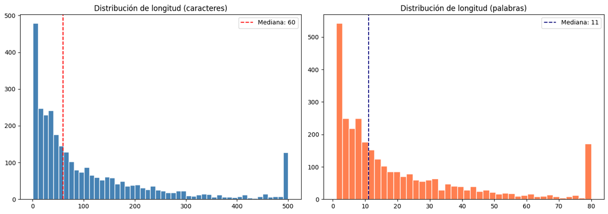

```
Mediana: 60 chars | 11 words
```

```python
df_raw['char_len'] = df_raw['text'].str.len()
df_raw['word_len'] = df_raw['text'].str.split().str.len()

fig, axes = plt.subplots(1, 2, figsize=(14, 5))
axes[0].hist(df_raw['char_len'].clip(upper=500), bins=50, color='steelblue', edgecolor='white')
axes[0].set_title('Distribución de longitud (caracteres)')
axes[0].axvline(df_raw['char_len'].median(), color='red', linestyle='--',
                label=f'Mediana: {df_raw["char_len"].median():.0f}')
axes[0].legend()
axes[1].hist(df_raw['word_len'].clip(upper=80), bins=40, color='coral', edgecolor='white')
axes[1].set_title('Distribución de longitud (palabras)')
axes[1].axvline(df_raw['word_len'].median(), color='navy', linestyle='--',
                label=f'Mediana: {df_raw["word_len"].median():.0f}')
axes[1].legend()
plt.tight_layout()
plt.savefig('data/processed/dist_longitud.png', bbox_inches='tight')
plt.show()
print(f"Mediana: {df_raw['char_len'].median():.0f} chars | {df_raw['word_len'].median():.0f} words")
```

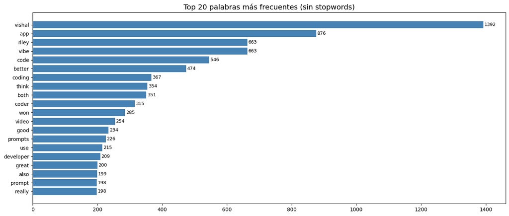

```python
STOPWORDS = {
    'the','a','an','is','it','in','to','of','and','or','i','this','that','for',
    'you','he','she','they','we','with','as','at','be','was','are','have','has',
    'had','but','not','do','did','so','if','by','on','your','my','his','her',
    'its','just','can','will','would','could','like','what','when','how','who',
    'there','here','from','all','one','no','up','out','about','get','got','into',
    'more','even','than','me','him','them','us','been','were','their','our',
    'im','ive','dont','doesnt','cant','hes','shes','thats'
}
all_words = []
for text in df_raw['text']:
    words = re.findall(r'\b[a-z]{3,}\b', str(text).lower())
    all_words.extend([w for w in words if w not in STOPWORDS])

word_freq = Counter(all_words).most_common(20)
words_list, counts = zip(*word_freq)
fig, ax = plt.subplots(figsize=(14, 6))
bars = ax.barh(list(reversed(words_list)), list(reversed(counts)), color='steelblue')
ax.set_title('Top 20 palabras más frecuentes (sin stopwords)', fontsize=14)
for bar, count in zip(bars, reversed(counts)):
    ax.text(bar.get_width() + 3, bar.get_y() + bar.get_height()/2, str(count), va='center', fontsize=9)
plt.tight_layout()
plt.savefig('data/processed/top_palabras.png', bbox_inches='tight')
plt.show()
```

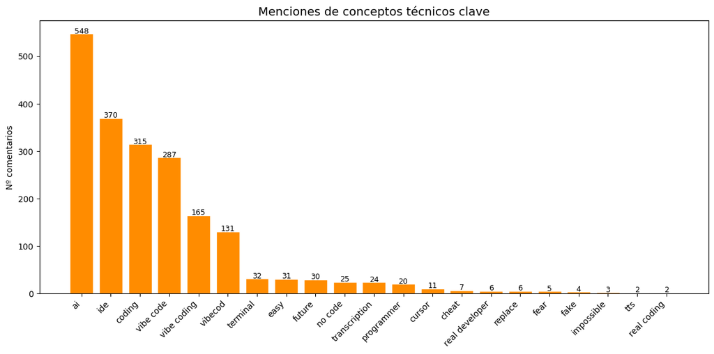

```
                menciones
ai                    548
ide                   370
coding                315
vibe code             287
vibe coding           165
vibecod               131
terminal               32
easy                   31
future                 30
no code                25
transcription          24
programmer             20
cursor                 11
cheat                   7
real developer          6
replace                 6
fear                    5
fake                    4
impossible              3
tts                     2
real coding             2
```

```python
concept_coverage = {c: df_raw['text'].str.lower().str.contains(c, na=False).sum() for c in CONCEPTS}
coverage_df = (pd.DataFrame.from_dict(concept_coverage, orient='index', columns=['menciones'])
               .query('menciones > 0').sort_values('menciones', ascending=False))

fig, ax = plt.subplots(figsize=(12, 6))
bars = ax.bar(coverage_df.index, coverage_df['menciones'], color='darkorange', edgecolor='white')
ax.set_title('Menciones de conceptos técnicos clave', fontsize=14)
ax.set_ylabel('Nº comentarios')
plt.xticks(rotation=45, ha='right')
for bar, val in zip(bars, coverage_df['menciones']):
    ax.text(bar.get_x() + bar.get_width()/2, bar.get_height() + 0.5, str(val), ha='center', fontsize=9)
plt.tight_layout()
plt.savefig('data/processed/concept_coverage.png', bbox_inches='tight')
plt.show()
print(coverage_df)
```

# Fase 3: Data Preparation

## 3a. Limpieza

```python
def clean_text(text: str) -> str:
    text = str(text)
    text = re.sub(r'http\S+|www\S+', '', text)
    text = re.sub(r'@\w+', '', text)
    text = re.sub(r'\s+', ' ', text).strip()
    return text

def is_meaningful(text: str) -> bool:
    return len(re.sub(r'[^\w]', '', text)) >= 10

df = df_raw.copy()
df['text_clean'] = df['text'].apply(clean_text)
df['meaningful'] = df['text_clean'].apply(is_meaningful)

print(f"Originales:       {len(df)}")
print(f"Sin sentido:      {(~df['meaningful']).sum()}")
df = df[df['meaningful']].drop_duplicates(subset='text_clean').reset_index(drop=True)
print(f"Después limpieza: {len(df)}")

df[['author','text','text_clean','votes','time','replies']].to_csv(DATA_CLEAN, index=False)
print(f"✓ Guardado: {DATA_CLEAN}")
```

```
Originales:       3007
Sin sentido:      519
Después limpieza: 2346
✓ Guardado: data\processed\comments_clean.csv
```

## 3b. Embeddings

```python
print("Cargando sentence-transformers...")
embed_model = SentenceTransformer('all-MiniLM-L6-v2')
print(f"✓ Dim: {embed_model.get_sentence_embedding_dimension()}")

print(f"\nGenerando embeddings para {len(df)} comentarios (1-3 min CPU)...")
embeddings = embed_model.encode(
    df['text_clean'].tolist(),
    batch_size=64, show_progress_bar=True,
    convert_to_numpy=True, normalize_embeddings=True
)
np.save(EMBEDDINGS_PATH, embeddings)
print(f"✓ Shape: {embeddings.shape} | Guardado: {EMBEDDINGS_PATH}")
```

```
Cargando sentence-transformers...
```

[output not shown]

```
✓ Dim: 384

Generando embeddings para 2346 comentarios (1-3 min CPU)...
```

```
✓ Shape: (2346, 384) | Guardado: data\processed\embeddings.npy
```

# Fase 4: Modeling

## 4a. Sentiment Analysis (VADER)

```python
sia = SentimentIntensityAnalyzer()

def get_sentiment(text: str) -> dict:
    s = sia.polarity_scores(text)
    c = s['compound']
    return {'compound': c, 'sentiment': 'positive' if c>=0.05 else ('negative' if c<=-0.05 else 'neutral'),
            'pos': s['pos'], 'neg': s['neg'], 'neu': s['neu']}

df = pd.concat([df, df['text_clean'].apply(get_sentiment).apply(pd.Series)], axis=1)
print(df['sentiment'].value_counts())
print(f"\nCompound promedio: {df['compound'].mean():.3f}")
```

```
sentiment
positive    1617
neutral      412
negative     317
Name: count, dtype: int64

Compound promedio: 0.384
```

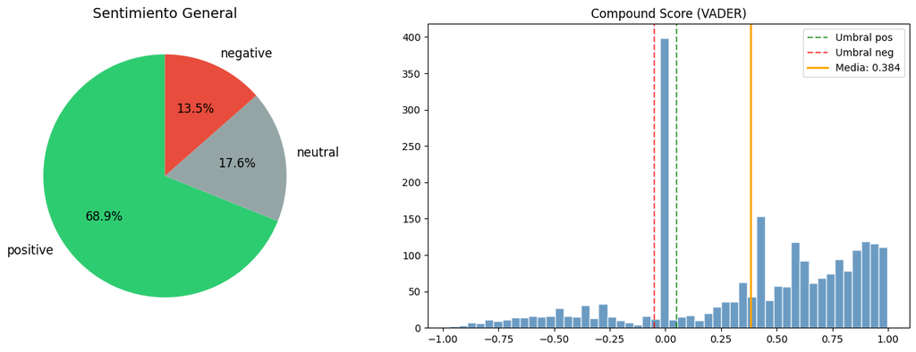

```python
sent_counts = df['sentiment'].value_counts()
colors = {'positive': '#2ecc71', 'neutral': '#95a5a6', 'negative': '#e74c3c'}

fig, axes = plt.subplots(1, 2, figsize=(14, 5))
axes[0].pie(sent_counts.values, labels=sent_counts.index,
            colors=[colors[s] for s in sent_counts.index],
            autopct='%1.1f%%', startangle=90, textprops={'fontsize':12})
axes[0].set_title('Sentimiento General', fontsize=14)

axes[1].hist(df['compound'], bins=50, color='steelblue', edgecolor='white', alpha=0.8)
for v, c, lbl in [(0.05,'green','Umbral pos'), (-0.05,'red','Umbral neg')]:
    axes[1].axvline(v, color=c, linestyle='--', alpha=0.7, label=lbl)
axes[1].axvline(df['compound'].mean(), color='orange', linewidth=2,
                label=f'Media: {df["compound"].mean():.3f}')
axes[1].set_title('Compound Score (VADER)'); axes[1].legend()
plt.tight_layout()
plt.savefig('data/processed/sentiment_general.png', bbox_inches='tight')
plt.show()
```

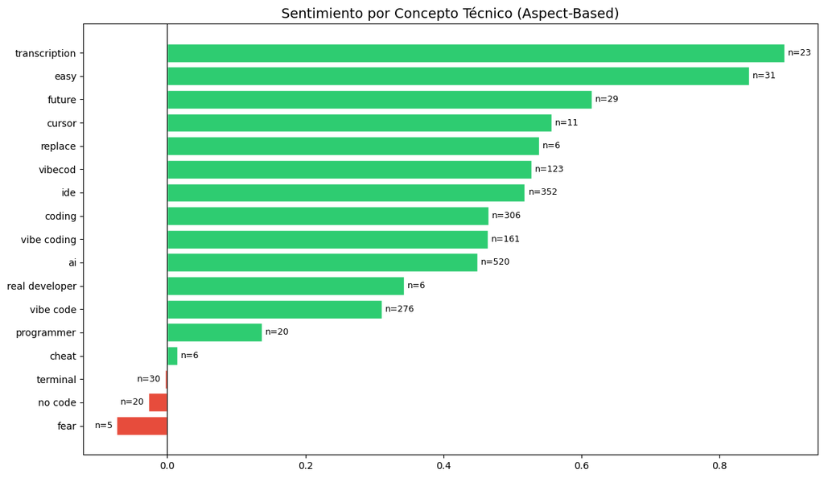

```
       concept  count  mean_compound  pct_positive  pct_negative
          fear      5      -0.073400      0.600000      0.400000
       no code     20      -0.028095      0.450000      0.550000
      terminal     30      -0.003793      0.400000      0.466667
         cheat      6       0.014283      0.500000      0.500000
    programmer     20       0.136985      0.550000      0.250000
     vibe code    276       0.311112      0.619565      0.217391
real developer      6       0.342667      0.666667      0.166667
            ai    520       0.449011      0.738462      0.167308
   vibe coding    161       0.464641      0.751553      0.105590
        coding    306       0.465360      0.761438      0.124183
           ide    352       0.518102      0.801136      0.139205
       vibecod    123       0.527451      0.804878      0.105691
       replace      6       0.538917      1.000000      0.000000
        cursor     11       0.557191      0.636364      0.000000
        future     29       0.614755      0.793103      0.137931
          easy     31       0.843097      1.000000      0.000000
 transcription     23       0.894113      1.000000      0.000000
```

```python
aspect_results = []
for concept in CONCEPTS:
    mask = df['text_clean'].str.lower().str.contains(concept, na=False)
    sub = df[mask]
    if len(sub) >= 5:
        aspect_results.append({'concept': concept, 'count': len(sub),
            'mean_compound': sub['compound'].mean(),
            'pct_positive': (sub['sentiment']=='positive').mean(),
            'pct_negative': (sub['sentiment']=='negative').mean()})

aspect_df = pd.DataFrame(aspect_results).sort_values('mean_compound')
fig, ax = plt.subplots(figsize=(12, 7))
bar_colors = ['#e74c3c' if x < 0 else '#2ecc71' for x in aspect_df['mean_compound']]
bars = ax.barh(aspect_df['concept'], aspect_df['mean_compound'], color=bar_colors, edgecolor='white')
ax.axvline(0, color='black', linewidth=0.8)
ax.set_title('Sentimiento por Concepto Técnico (Aspect-Based)', fontsize=14)
for bar, count in zip(bars, aspect_df['count']):
    x = bar.get_width()
    ax.text(x+(0.005 if x>=0 else -0.005), bar.get_y()+bar.get_height()/2,
            f'n={count}', va='center', fontsize=9, ha='left' if x>=0 else 'right')
plt.tight_layout()
plt.savefig('data/processed/aspect_sentiment.png', bbox_inches='tight')
plt.show()
print(aspect_df.to_string(index=False))
```

## 4b. Clustering: UMAP + HDBSCAN

```python
print("UMAP 10D (clustering)...")
reducer_10d = umap.UMAP(n_components=10, n_neighbors=20, min_dist=0.0, metric='cosine', random_state=42)
embedding_10d = reducer_10d.fit_transform(embeddings)
print(f"✓ {embedding_10d.shape}")
```

```
UMAP 10D (clustering)...
✓ (2346, 10)
```

```python
print("UMAP 2D (visualización)...")
reducer_2d = umap.UMAP(n_components=2, n_neighbors=20, min_dist=0.1, metric='cosine', random_state=42)
embedding_2d = reducer_2d.fit_transform(embeddings)
print(f"✓ {embedding_2d.shape}")
```

```
UMAP 2D (visualización)...
✓ (2346, 2)
```

```python
clusterer = hdbscan.HDBSCAN(min_cluster_size=30, min_samples=10,
                             metric='euclidean', cluster_selection_method='eom')
cluster_labels = clusterer.fit_predict(embedding_10d)

n_clusters = len(set(cluster_labels)) - (1 if -1 in cluster_labels else 0)
print(f"✓ Clusters: {n_clusters}")
for label in sorted(set(cluster_labels)):
    name = "RUIDO" if label == -1 else f"Cluster {label}"
    count = (cluster_labels == label).sum()
    print(f"  {name}: {count} ({count/len(cluster_labels):.1%})")

df['cluster'] = cluster_labels
df['umap_x'] = embedding_2d[:, 0]
df['umap_y'] = embedding_2d[:, 1]
df.to_csv(CLUSTERS_PATH, index=False)
print(f"✓ Guardado: {CLUSTERS_PATH}")
```

```
✓ Clusters: 17
  RUIDO: 498 (21.2%)
  Cluster 0: 44 (1.9%)
  Cluster 1: 50 (2.1%)
  Cluster 2: 42 (1.8%)
  Cluster 3: 107 (4.6%)
  Cluster 4: 186 (7.9%)
  Cluster 5: 142 (6.1%)
  Cluster 6: 193 (8.2%)
  Cluster 7: 87 (3.7%)
  Cluster 8: 58 (2.5%)
  Cluster 9: 60 (2.6%)
  Cluster 10: 111 (4.7%)
  Cluster 11: 39 (1.7%)
  Cluster 12: 53 (2.3%)
  Cluster 13: 91 (3.9%)
  Cluster 14: 94 (4.0%)
  Cluster 15: 133 (5.7%)
  Cluster 16: 358 (15.3%)
✓ Guardado: data\processed\clusters.csv
```

```python
df['cluster_str'] = df['cluster'].apply(lambda x: 'Ruido' if x==-1 else f'Cluster {x}')
fig = px.scatter(df, x='umap_x', y='umap_y', color='cluster_str',
    hover_data={'text_clean':True,'sentiment':True,'votes':True,'umap_x':False,'umap_y':False},
    title='Clusters de Comentarios (UMAP 2D + HDBSCAN)', opacity=0.6, width=900, height=600)
fig.update_traces(marker=dict(size=4))
fig.show()
```

[output not shown]

```python
def get_representative_comments(cluster_id: int, n: int = 10) -> pd.DataFrame:
    mask = df['cluster'] == cluster_id
    cluster_embs = embeddings[mask]
    centroid = cluster_embs.mean(axis=0, keepdims=True)
    sims = cosine_similarity(centroid, cluster_embs)[0]
    top_idx = sims.argsort()[-n:][::-1]
    return df[mask].iloc[top_idx][['text_clean','votes','sentiment','compound']]

for label in sorted([l for l in set(cluster_labels) if l != -1]):
    print(f"\n{'='*60}\nCLUSTER {label} — Top 10\n{'='*60}")
    for _, row in get_representative_comments(label).iterrows():
        print(f"[{row['sentiment']:8s}|{row['compound']:+.2f}|👍{row['votes']}] {row['text_clean'][:120]}")
```

```
============================================================
CLUSTER 0 — Top 10
============================================================
[positive|+0.36|👍30] cd Cereal, what does that mean? 😅
[positive|+0.82|👍0] lol "cd cereal what does this mean" 😂😂
[neutral |+0.00|👍0] cd cereal - what does that mean? Cearaously?!?
[neutral |+0.00|👍1] cd Cereal what does that mean????? cmon man
[neutral |+0.00|👍464] 'cd cereal what does that mean ?' Bro 💀
[positive|+0.77|👍0] Wow, asking what "cd cereal" is? 😂
[positive|+0.42|👍0] This guy actually asked "What does 'cd Cereal' mean?" lol
[neutral |+0.00|👍0] "cd cereal, what does that mean?"
[neutral |+0.00|👍0] "CD Cereal.. what does that mean?" ☠💀
[positive|+0.38|👍1] "cd Cereal - what does that mean?" oh dear, vibecoder...

============================================================
CLUSTER 1 — Top 10
============================================================
[negative|-0.56|👍0] They lost me at ...what is cd? ...and the terminal makes me scared. This truly makes a point that pure vibecoders are us
[neutral |+0.00|👍0] bro just asked what "cd" means hahahahahahahahaha
[neutral |+0.00|👍2] Hahahaha the comment I was looking for!! I’m a newb vibe coder and even I know what cd means in cmd
[negative|-0.97|👍0] … Cd .. what’s that mean? 😱😱😱😱
[negative|-0.36|👍0] Jesus, that vibe "coder" is like a child. What is the CD? OMG, you really don't know how to use a terminal? WTF? How can
[negative|-0.40|👍0] Damn. A vibe coder that asks what CD means.
[negative|-0.89|👍0] why this comment is not top?? that's not real.... what is "cd" terminal is "SCARY" WTF...
[positive|+0.23|👍0] LOL so he pretend to be some kind of thech dude, but did not even know what cd is doing in a terminal.
[neutral |+0.00|👍0] Did you legit ask what “cd” is? Man, I’m old if new programmers don’t know shell commands to navigate directories.
[neutral |+0.00|👍0] 4:38 a vibe coder don't know whats mean cd in terminal! Damnnn, man, you are a real vibe coder!

============================================================
CLUSTER 2 — Top 10
============================================================
[positive|+0.44|👍0] riley's app is better
[positive|+0.44|👍0] Riley's app seems to work better tbh
[neutral |+0.00|👍0] kinda prefer riley's app
[positive|+0.44|👍0] riley app was better
[positive|+0.44|👍0] Riley app is simple and good. We shall see. I vote for Riley.
[neutral |+0.00|👍0] Prefer Riley's app
[positive|+0.42|👍0] I liked Rileys app. Just feels a bit more intutive & simpler.
[positive|+0.81|👍0] I like Riley's app better because while having all needed features it has a better UI in my opinion.
[positive|+0.70|👍0] Riley- your app is better, simple and works better
```

[output cut: 182 more lines]

```
[negative|-0.92|👍1] People think that devs are going to develop AI and not use it, that you think you can use it does not make you belonging

============================================================
CLUSTER 16 — Top 10
============================================================
[negative|-0.40|👍0] This is just vibe-vs-vibe. It's nonsense. An unleashed senior dev could out-code a vibe coder any day of the week.
[positive|+0.44|👍0] Vibe coder may win—until an expert starts vibe coding. 😂
[neutral |+0.00|👍0] this is a vibe coder vs vibe coder
[neutral |+0.00|👍190] So this was basically vibe coder vs vibe coder
[negative|-0.51|👍0] dumb comparison when the real dev can't type code. Vibe coder is just afraid to touch the codes.
[neutral |+0.00|👍0] This is vibe coder vs ios developer + vibe coder.
[positive|+0.20|👍0] this is bullshit if you challenge a developer and your so proud at vibe coding. the developer should be able to touch co
[neutral |+0.00|👍0] Vibe code vs vibe code? I don't
[negative|-0.23|👍0] "Can a vibe coder make a better app than a senior iOS engineer (who is also being forced to vibe code for some odd reaso
[positive|+0.15|👍0] this was dumb lmao, Vibe coder vs vibe coder+
```

```python
VIDEO_CONTEXT = """
This video shows a friendly challenge between Riley Brown (a vibe coder using a no-code tool)
and Vishal Dwey (a senior iOS engineer using Claude Code). The task is to build a clone of
Granola, an AI note-taking app, in five prompts each.

Required app capabilities:
- Audio recording with automatic transcription
- Calendar integration to sync meetings
- AI-generated meeting summaries
- Folder organization for saved meetings

Both participants iteratively prompt, debug, and refine their apps. They face practical issues
like API key errors, rendering bugs, and UI/folder functionality problems. By the end, both
produce functional iOS apps with different strengths: no-code vibe coding speed vs native Swift
engineering depth.
""".strip()


def label_cluster_with_llm(cluster_id: int) -> str:
    reps = get_representative_comments(cluster_id, n=15)
    sample = "\n".join([f"- {t[:150]}" for t in reps['text_clean']])
    prompt = (
        f"Context for analysis:\n{VIDEO_CONTEXT}\n\n"
        f"Cluster of {len(df[df['cluster']==cluster_id])} similar YouTube comments:\n{sample}\n\n"
        "Tasks:\n"
        "1. What type of person likely writes these comments?\n"
        "2. What is their attitude toward vibe coding and AI-assisted development?\n"
        "3. Provide a short persona label (example: Skeptical Developer).\n"
        "Answer in concise bullet points."
    )
    r = ollama.chat(
        model='qwen3:1.7b',
        messages=[{'role': 'user', 'content': prompt}],
        options={'temperature': 0.3},
    )
    return r['message']['content']

cluster_labels_dict = {}
for label in sorted([l for l in set(cluster_labels) if l != -1]):
    print(f"\n--- Cluster {label} ---")
    desc = label_cluster_with_llm(label)
    cluster_labels_dict[label] = desc
    print(desc)
```

```
--- Cluster 0 ---
- **Person Type:** Amused Critic (mocking no-code vibe coding)
- **Attitude Toward Vibe Coding:** Skeptical, frustrated with inefficiency and bugs, appreciates native depth
- **Persona Label:** Skeptical Developer

--- Cluster 1 ---
- **Personality Type**: Skeptical Developer
- **Attitude Toward Vibe Coding**: Criticized as uninformed, dismissive of technical skills, and skeptical of AI-assisted tools.
- **Emotional Tone**: Mocking, frustrated, and dismissive of no-code/ai-assisted development.

--- Cluster 2 ---
- **Personality Type**: User Advocate
- **Attitude Toward Vibe Coding**: Positive, appreciating simplicity and functionality
- **Attitude Toward AI-Assisted Development**: Supportive, recognizing value in no-code tools and AI integration
- **Persona Label**: User Advocate

--- Cluster 3 ---
- **Person Type**: Enthusiastic User (positive, supportive, impressed by no-code capabilities)
- **Attitude Toward Vibe Coding**: Admiring and enthusiastic, seeing it as efficient and effective.
- **Persona Label**: Fan of No-Code

--- Cluster 4 ---
- **Person Type**: Casual Viewer / Enthusiast
- **Attitude Toward Vibe Coding**: Appreciative / Curious (enjoys the creative challenge)
- **Persona Label**: Creative Viewer

--- Cluster 5 ---
- **Personality Type**: Tech Enthusiast
- **Attitude Toward Vibe Coding**: Mixed admiration for its ease and creativity, with critiques of polish and technical depth.
- **Persona Label**: Tech Enthusiast (e.g., "Informed User" or "Developer Advocate")

--- Cluster 6 ---
- **Personality Type**: Tech Enthusiast
- **Attitude Toward Vibe Coding**: Positive, appreciating speed and simplicity but acknowledging strengths of native development.
- **Attitude Toward AI-Assisted Development**: Neutral, recognizing value in AI tools while valuing craftsmanship in native apps.

--- Cluster 7 ---
- **Personality Type**: Skeptical Developer
- **Attitude Toward Vibe Coding**: Critical, questioning the quality and depth of no-code solutions.
- **Attitude Toward AI-Assisted Development**: Mixed; acknowledges speed but highlights flaws in functionality and reliability.
```

[output cut: 30 more lines]

```

--- Cluster 14 ---
- **Person Type**: Experienced iOS developer with a preference for native coding.
- **Attitude Toward Vibe Coding**: Skeptical, as the comments highlight flaws in no-code tools (e.g., API errors, rendering issues).
- **Persona Label**: Skeptical Developer.

--- Cluster 15 ---
- **Personality Type**: Skeptical Developer
- **Attitude Toward Vibe Coding/AI**: Criticizes no-code AI tools for inefficiency, emphasizes human expertise, and views AI as a tool that can't replace deep technical skills.
- **Key Insight**: Values professional development over AI shortcuts, mocks AI's limitations, and prefers human-led coding.

--- Cluster 16 ---
- **Person Type**: Skeptical Developer
- **Attitude Toward Vibe Coding**: Criticizes AI-assisted development as inferior, mocks "vibe coders" for lacking real coding skills, and believes only experts can create quality apps.
- **Persona Label**: Skeptical Developer
```

## 4c. Grafo de Co-ocurrencia de Conceptos

```python
df['concepts_found'] = df['text_clean'].apply(
    lambda t: [c for c in CONCEPTS if c in t.lower()])

concept_freq = Counter()
co_occurrence = Counter()
for concepts in df['concepts_found']:
    concept_freq.update(concepts)
    if len(concepts) >= 2:
        for pair in combinations(sorted(concepts), 2):
            co_occurrence[pair] += 1

print(f"Nodos: {sum(1 for n in concept_freq.values() if n > 0)}, Aristas: {len(co_occurrence)}")
print("\nTop 10 conceptos:")
for c, n in concept_freq.most_common(10): print(f"  {c}: {n}")
print("\nTop 10 co-ocurrencias:")
for (c1,c2), n in co_occurrence.most_common(10): print(f"  {c1} ↔ {c2}: {n}")
```

```
Nodos: 21, Aristas: 96

Top 10 conceptos:
  ai: 520
  ide: 352
  coding: 306
  vibe code: 276
  vibe coding: 161
  vibecod: 123
  easy: 31
  terminal: 30
  future: 29
  transcription: 23

Top 10 co-ocurrencias:
  coding ↔ vibe coding: 161
  ai ↔ ide: 131
  ai ↔ coding: 121
  ai ↔ vibe code: 98
  coding ↔ ide: 83
  ide ↔ vibe code: 59
  ai ↔ vibe coding: 56
  coding ↔ vibe code: 49
  ai ↔ vibecod: 38
  ide ↔ vibe coding: 37
```

```
Grafo: 18 nodos, 66 aristas
```

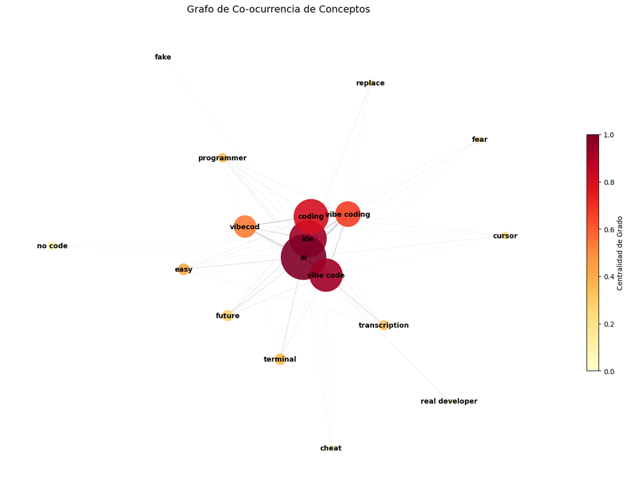

```python
G = nx.Graph()
for concept, freq in concept_freq.items():
    if freq >= 3: G.add_node(concept, frequency=freq)
for (c1, c2), weight in co_occurrence.items():
    if weight >= 2 and G.has_node(c1) and G.has_node(c2):
        G.add_edge(c1, c2, weight=weight)

print(f"Grafo: {G.number_of_nodes()} nodos, {G.number_of_edges()} aristas")
pos = nx.spring_layout(G, k=2.5, seed=42, weight='weight')
node_sizes = [concept_freq[n] * 8 for n in G.nodes()]
edge_weights = [G[u][v]['weight'] for u, v in G.edges()]
max_w = max(edge_weights) if edge_weights else 1

fig, ax = plt.subplots(figsize=(14, 10))
centrality = nx.degree_centrality(G)
nx.draw_networkx_nodes(G, pos, node_size=node_sizes,
                       node_color=[centrality[n] for n in G.nodes()],
                       cmap=plt.cm.YlOrRd, alpha=0.9, ax=ax)
nx.draw_networkx_edges(G, pos, width=[w/max_w*6 for w in edge_weights],
                       alpha=0.4, edge_color='gray', ax=ax)
nx.draw_networkx_labels(G, pos, font_size=10, font_weight='bold', ax=ax)
ax.set_title('Grafo de Co-ocurrencia de Conceptos', fontsize=14); ax.axis('off')
sm = plt.cm.ScalarMappable(cmap=plt.cm.YlOrRd, norm=plt.Normalize(0,1))
plt.colorbar(sm, ax=ax, label='Centralidad de Grado', shrink=0.5)
plt.tight_layout()
plt.savefig('data/processed/concept_graph.png', bbox_inches='tight', dpi=150)
plt.show()
```

```python
degree_c = nx.degree_centrality(G)
between_c = nx.betweenness_centrality(G, weight='weight')
eigen_c   = nx.eigenvector_centrality(G, weight='weight', max_iter=500)

centrality_df = pd.DataFrame({
    'concept': list(G.nodes()),
    'frequency': [concept_freq[n] for n in G.nodes()],
    'degree': [degree_c[n] for n in G.nodes()],
    'betweenness': [between_c[n] for n in G.nodes()],
    'eigenvector': [eigen_c[n] for n in G.nodes()],
}).sort_values('degree', ascending=False)
print("Top 10 conceptos más conectados:")
print(centrality_df.head(10).to_string(index=False))
```

```
Top 10 conceptos más conectados:
      concept  frequency   degree  betweenness  eigenvector
           ai        520 0.941176     0.052696     0.513004
          ide        352 0.882353     0.234069     0.422624
    vibe code        276 0.882353     0.204657     0.325582
       coding        306 0.764706     0.040441     0.518042
  vibe coding        161 0.647059     0.158088     0.392166
      vibecod        123 0.529412     0.079657     0.135944
         easy         31 0.411765     0.000000     0.044721
   programmer         20 0.352941     0.000000     0.045045
     terminal         30 0.352941     0.018382     0.035056
transcription         23 0.352941     0.020833     0.040260
```

# Fase 5: Evaluation

```python
non_noise = df['cluster'] != -1
if non_noise.sum() > 1:
    sil = silhouette_score(embeddings[non_noise], df.loc[non_noise,'cluster'],
                           metric='cosine', sample_size=1000, random_state=42)
    print(f"Silhouette Score: {sil:.4f}  (>0.3 aceptable para texto)")

summary = df[non_noise].groupby('cluster').agg(
    tamaño=('text_clean','count'),
    compound_mean=('compound','mean'),
    pct_pos=('sentiment', lambda x: (x=='positive').mean()),
    pct_neg=('sentiment', lambda x: (x=='negative').mean()),
    likes_mean=('votes','mean'),
    likes_max=('votes','max'),
).round(3)
print("\nResumen por Cluster:")
print(summary.to_string())
```

```
Silhouette Score: 0.0986  (>0.3 aceptable para texto)

Resumen por Cluster:
         tamaño  compound_mean  pct_pos  pct_neg  likes_mean  likes_max
cluster
0            44          0.165    0.455    0.136      11.477        464
1            50          0.017    0.380    0.360       2.520         92
2            42          0.495    0.762    0.071       0.119          2
3           107          0.406    0.692    0.093       0.299         27
4           186          0.281    0.634    0.151       0.731         75
5           142          0.738    0.930    0.028       3.542        208
6           193          0.576    0.891    0.021       0.839         80
7            87          0.226    0.563    0.172       0.517         18
8            58          0.386    0.690    0.086       0.155          3
9            60          0.685    0.917    0.033       0.817         25
10          111          0.616    0.883    0.054       0.667         20
11           39          0.483    0.821    0.000       0.103          2
12           53          0.062    0.434    0.415      12.736        366
13           91          0.599    0.956    0.022       0.637         28
14           94          0.256    0.521    0.053       0.074          2
15          133          0.245    0.586    0.211       0.872         31
16          358          0.215    0.545    0.215       2.726        246
```

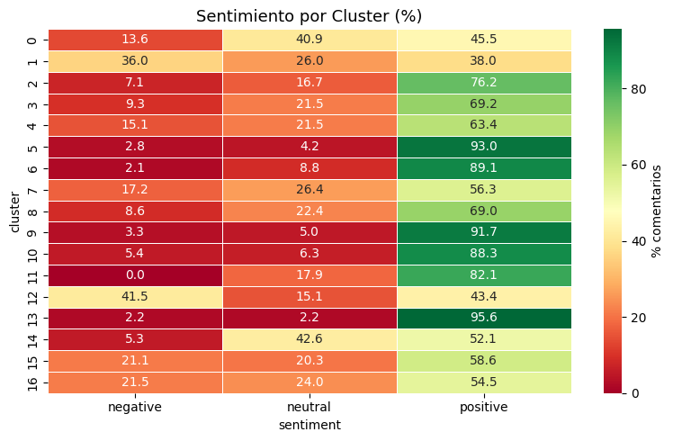

```python
cross = pd.crosstab(df[df['cluster']!=-1]['cluster'],
                    df[df['cluster']!=-1]['sentiment'], normalize='index') * 100
fig, ax = plt.subplots(figsize=(8, 5))
sns.heatmap(cross, annot=True, fmt='.1f', cmap='RdYlGn',
            linewidths=0.5, ax=ax, cbar_kws={'label':'% comentarios'})
ax.set_title('Sentimiento por Cluster (%)', fontsize=13)
plt.tight_layout()
plt.savefig('data/processed/cluster_sentiment_heatmap.png', bbox_inches='tight')
plt.show()
```

```python
print("=" * 60)
print("VALIDACIÓN DE HIPÓTESIS")
print("=" * 60)
for concept in ['ide', 'terminal', 'vibe coding', 'real developer', 'replace', 'fear']:
    mask = df['text_clean'].str.lower().str.contains(concept, na=False)
    if mask.sum() >= 5:
        avg = df[mask]['compound'].mean()
        pct_neg = (df[mask]['sentiment']=='negative').mean() * 100
        print(f"\n'{concept}' ({mask.sum()} comentarios):")
        print(f"  Compound promedio: {avg:+.3f} | % negativos: {pct_neg:.1f}%")
```

```
============================================================
VALIDACIÓN DE HIPÓTESIS
============================================================

'ide' (352 comentarios):
  Compound promedio: +0.518 | % negativos: 13.9%

'terminal' (30 comentarios):
  Compound promedio: -0.004 | % negativos: 46.7%

'vibe coding' (161 comentarios):
  Compound promedio: +0.465 | % negativos: 10.6%

'real developer' (6 comentarios):
  Compound promedio: +0.343 | % negativos: 16.7%

'replace' (6 comentarios):
  Compound promedio: +0.539 | % negativos: 0.0%

'fear' (5 comentarios):
  Compound promedio: -0.073 | % negativos: 40.0%
```

# Fase 6: Deployment — Mini RAG con qwen3:1.7b

```python
def ask(query: str, k: int = 15, model: str = 'qwen3:1.7b') -> str:
    query_emb = embed_model.encode([query], normalize_embeddings=True)
    scores = (embeddings @ query_emb.T).flatten()
    top_idx = scores.argsort()[-k:][::-1]
    context = "\n".join(
        f"[{row['sentiment']}|cluster={row['cluster']}] {row['text_clean']}"
        for _, row in df.iloc[top_idx][['text_clean','sentiment','cluster']].iterrows()
    )
    prompt = (
            f"Context for analysis:\n{VIDEO_CONTEXT}\n\n"
            f"You analyze YouTube comments about vibe coding "
            f"(non-programmer builds app with AI, unaware of IDE/terminal).\n\n"
            f"{k} relevant comments:\n{context}\n\n"
            f"Question: {query}\n"
            f"Answer analytically. Cite 2-3 specific comments.")
    r = ollama.chat(model=model, messages=[{'role':'user','content':prompt}],
                    options={'temperature':0.3})
    return r['message']['content']

try:
    test = ollama.chat(model='qwen3:1.7b', messages=[{'role':'user','content':'Say OK'}],
                       options={'temperature':0})
    print(f"✓ Ollama OK: {test['message']['content']}")
except Exception as e:
    print(f"✗ Error: {e} — ejecutá 'ollama serve' en otra terminal")
```

```
✓ Ollama OK: OK. How can I assist you today?
```

```python
queries = [
    "What do professional developers think about vibe coding?",
    "Are people surprised that Riley doesn't know what an IDE or terminal is?",
    "Do people think AI tools will replace real programming skills?",
    "What do non-technical people say about the video?",
    "Is there a debate about whether vibe coding is real coding?"
]
for q in queries:
    print(f"\n{'='*60}\nQ: {q}\n{'='*60}")
    print(ask(q))
```

```
============================================================
Q: What do professional developers think about vibe coding?
============================================================
Professional developers, as highlighted in the comments, view **vibe coding** through a lens of **tool dependency**, **skill gap**, and **practical limitations**, while acknowledging its potential for rapid prototyping. Here are 2–3 key insights from the comments:

1. **Comparative Evaluation of Skill Levels**:
   A comment explicitly contrasts **professional developers** with **vibe coders**. It states:
   *"I think it would be more interesting to compare what a professional developer can achieve in a set timeframe without 'vibecoding' versus what a vibecoder produces, specifically to see the differences in quality and quantity."*
   This underscores the **value of direct comparison** between professional coding and non-technical, tool-heavy approaches. Professional developers are expected to **understand tools** (e.g., terminals, APIs) and **craft robust code**, which vibe coders often lack due to reliance on AI.

2. **Critique of Tool Dependency**:
   Another comment highlights the **risk of relying on AI for critical tasks**:
   *"Enterprises relying on vibe coders not understanding basic stuff like CD on a terminal will fail."*
   This reflects a **practical concern** about **tool proficiency**. Professional developers are expected to **master tools** (e.g., Git, terminal commands) and **debug issues** manually, whereas vibe coders may prioritize speed over depth, leading to **inadequate infrastructure** or **poor code qua…

3. **Long-Term Productivity vs. Short-Term Efficiency**:
   A third comment notes:
   *"A dev vibe coder will have better results in the long run because he will check gradually the quality of code."*
   This contrasts the **short-term efficiency** of vibe coding (e.g., rapid prototyping) with the **long-term benefits** of **code review** and **refinement**. Professional developers are trained to **prioritize quality** over speed, which is a **core strength** of their approach.

### Summary:
Professional developers view vibe coding as a **tool for rapid prototyping** but emphasize the **importance of tool mastery** and **code quality**. While vibe coders may produce **quick, functional solutions**, professionals are expected to **understand the limitations** of AI-generated code and **r…

============================================================
Q: Are people surprised that Riley doesn't know what an IDE or terminal is?
============================================================
**Answer:**
People are not surprised that Riley doesn't know about IDEs or terminals, as the relevant comments do not explicitly mention these tools. The critiques focus on Riley's lack of expertise in the subject matter (e.g., "This guy Riley knows nothing" or "Riley is just an egocentric") rather than the too…

**Citations:**
1. **[negative|cluster=3]**: "This guy Riley knows nothing 😭😭 his questions are insane" – Critiques his lack of knowledge in the subject matter, not the tools.
2. **[neutral|cluster=3]**: "Riley. For me he came away with a more usable interface" – Focuses on the app's usability, not the tools.
3. **[positive|cluster=10]**: "To improve thinking process of vibe coders. I guess Riley is not pure vibe coder, he understand the process to well" – Highlights his understanding of the process, not the tools.

The comments collectively emphasize Riley's ability to create functional apps despite not being a traditional developer, rather than addressing the technical tools he uses. Thus, there is no indication of surprise about his lack of familiarity with IDEs or terminals.

============================================================
Q: Do people think AI tools will replace real programming skills?
============================================================
**Answer:**
```

[output cut: 27 more lines]

```
These comments reveal that non-technical viewers see the video as a comedic take on the "AI vs human" narrative, criticizing its title, the lack of real engineering skill, and the absurdity of the scenario.

============================================================
Q: Is there a debate about whether vibe coding is real coding?
============================================================
Yes, there is a debate about whether vibe coding is "real coding," as evidenced by the nuanced comments in the YouTube comments cluster. The debate centers on whether vibe coding (non-programmer AI-driven app development) constitutes legitimate coding or is merely a form of "magic" executed by AI. H…

1. **Critique of "Real Coding" Status**:
   The comment **"[negative|cluster=16] Vibecoding = no knowledge about coding ?"** directly challenges the legitimacy of vibe coding as "real coding." It implies that vibe coding is not a genuine form of coding because it relies on AI to generate code, which some argue undermines the skill or effor…

2. **Contrast with "Real Coding"**:
   The comment **"[positive|cluster=16] Comparing vibe coding to real coding by a senior to achieve the same project would be more interesting, imo."** highlights the tension between vibe coding and traditional coding. While it acknowledges that vibe coding is AI-driven, it also suggests that the co…

### Key Takeaway:
The debate is not about whether vibe coding is "real" in the technical sense (i.e., whether it involves actual coding skills), but whether it is considered "real" in the context of the project itself. Some comments argue it is not real coding (due to AI reliance), while others view it as a legitimat…
```

```python
# Modo interactivo — escribe tus propias preguntas
while True:
    query = input("\n🔍 Tu pregunta (o 'exit'): ").strip()
    if query.lower() in ('exit', 'quit', 'q', ''):
        break
    print("\n" + ask(query))
```